# importing dataset

# calculates silhouette scores for the clustering results using the

silhouette function and visualizes them using fviz_silhouette.

```
  cluster size ave.sil.width
1       1  776          0.33
2       2 1547          0.26
3       3  489          0.26
4       4 1198          0.39
```

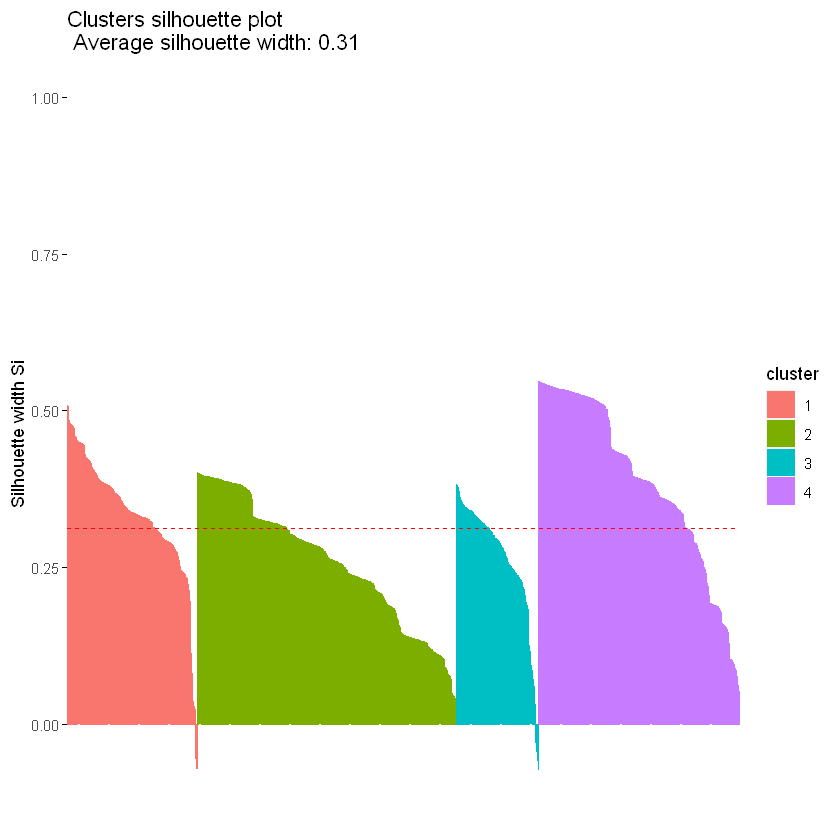

```r
#Cluster Validation
library(cluster)
#average for each cluster
avg_sil <- silhouette(kmns$cluster,dist(numeric_dataset))
fviz_silhouette(avg_sil)
```

the graph shows an average silhouette width of 0.31, it falls in the moderate-low range. It suggests that there is a reasonable level of separation and coherence among the clusters, but there may still be some overlap or ambiguity in the clustering results.

# calculates and prints the within-cluster sum of squares (WCSS), which

is a measure of the compactness of clusters. and print it

```r
# Calculate the WCSS
wcss <- sum(kmns$withinss)

# Print the WCSS
print(wcss)
```

```
[1] 10358.26
```

the WCSS value of 10358.26 suggests that there is a relatively high amount of variation or spread within the clusters as a whole. This indicates that the data points within the clusters are not tightly packed around their respective centroids, and there may be significant overlap or uncertainty in the assignment of data points to clusters.

# defines a function 'calculate_bcubed_metrics' to compute BCubed

precision and recall. The function takes cluster assignments and ground truth labels(Status) as input and returns precision and recall. Then, it calculates and prints BCubed precision and recall for the clustering results. #BCubed Metrics

```r
cluster_assignments <- kmns$cluster
ground_truth_labels <- datawithcl$Status

calculate_bcubed_metrics <- function(cluster_assignments, ground_truth_labels) {
  precision_sum <- recall_sum <- 0

  for (i in seq_along(cluster_assignments)) {
    same_category_same_cluster <- sum(ground_truth_labels[cluster_assignments == cluster_assignments[i]] == ground_truth_labels[i])
    total_same_cluster <- sum(cluster_assignments == cluster_assignments[i])
    total_same_category <- sum(ground_truth_labels == ground_truth_labels[i])

    precision_sum <- precision_sum + same_category_same_cluster / total_same_cluster
    recall_sum <- recall_sum + same_category_same_cluster / total_same_category
  }

  precision <- precision_sum / length(cluster_assignments)
  recall <- recall_sum / length(cluster_assignments)

  return(list(precision = precision, recall = recall))
}

metrics <- calculate_bcubed_metrics(cluster_assignments, ground_truth_labels)
precision <- metrics$precision
recall <- metrics$recall

cat("BCubed Precision:", precision)
cat("BCubed Recall:", recall)
```

```
BCubed Precision: 0.7575418BCubed Recall: 0.3003604BCubed Recall: 0.3003604
```

BCubed Precision: The BCubed Precision measures the quality of clustering in terms of how accurately the data points within each cluster are assigned. The value of 0.7575418 indicates that, on average, around 75.75% of the data points within the same cluster are correctly assigned.

BCubed Recall: The BCubed Recall measures the completeness of clustering by evaluating how well the algorithm captures all the similar data points within each cluster. The value of 0.3003604 indicates that, on average, around 30.04% of the similar data points are captured within the same cluster.

From these results, we can conclude that the clustering algorithm has achieved relatively high precision (around 75.75%), indicating that the algorithm tends to assign data points correctly within each cluster. However, the recall value is relatively low (around 30.04%), suggesting that the algorithm may have missed capturing a significant portion of the similar data points within each cluster.

# Clustr of size=5 this number was chosen randomlly

```
K-means clustering with 5 clusters of sizes 1119, 768, 1147, 478, 498

Cluster means:
        Age     Race Marital.Status  T.Stage  N.Stage X6th.Stage differentiate
1 0.6029114 1.224307       1.153709 2.259160 1.279714   2.618409      1.829312
2 0.6143777 1.276042       4.225260 1.720052 1.253906   1.993490      2.143229
3 0.6152893 1.194420       1.141238 1.000000 1.103749   1.103749      1.993025
4 0.6122000 1.240586       1.941423 2.257322 2.981172   4.981172      2.384937
5 0.5674276 1.251004       1.182731 2.158635 1.357430   2.562249      3.020080
     Grade     A.Stage Tumor.Size Estrogen.Status Progesterone.Status
1 1.829312 0.009830206 0.29097273       0.9624665           0.8739946
2 2.143229 0.002604167 0.21010890       0.9335938           0.8203125
3 1.993025 0.000000000 0.09928403       0.9572799           0.8605057
4 2.384937 0.150627615 0.31719919       0.8661088           0.7322176
5 3.020080 0.014056225 0.27788426       0.8795181           0.7429719
```

[output cut: 519 more lines]

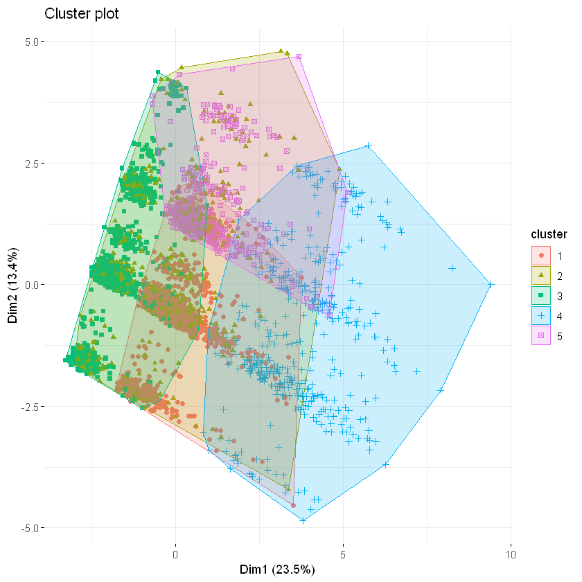

```r
kmns <- kmeans(numeric_dataset, 5, iter.max = 140 , algorithm="Lloyd", nstart=100)
kmns
#using the fviz_cluster function from the factoextra library to visualize the clustering results. The visualization includes points representing data, cluster centers, and ellipses around clusters.
library(factoextra)
fviz_cluster(kmns, data = numeric_dataset, geom = "point",
             show.clust.cent = FALSE, ellipse = TRUE,
             repel = TRUE, ggtheme = theme_minimal())
```